# Wie sicr 1.1.1 die Skowasch-Methode umsetzt

## Wie sicr 1.1.1 die Skowasch-Methode umsetzt

DAV-ERGEBNISBERICHT · METHODENPRÜFUNG

Paket sicr 1.1.1, Commit c0ad2ad · DAV-Ergebnisbericht vom 04.02.2025 · Stand nach drei Prüfrunden.

Codezeilen in den Fußzeilen beziehen sich auf sicr 1.1.1 @ c0ad2ad (Verzeichnis `R/` des Pakets).

Die elf Schritte der Methode und ihre Umsetzung: wo sicr folgt, wo es abweicht und welche Fehler Ergebnisse bewegen.

## Die Methode in elf Schritten

D.1–D.11 · CHECKLISTE AUS KAPITEL 2

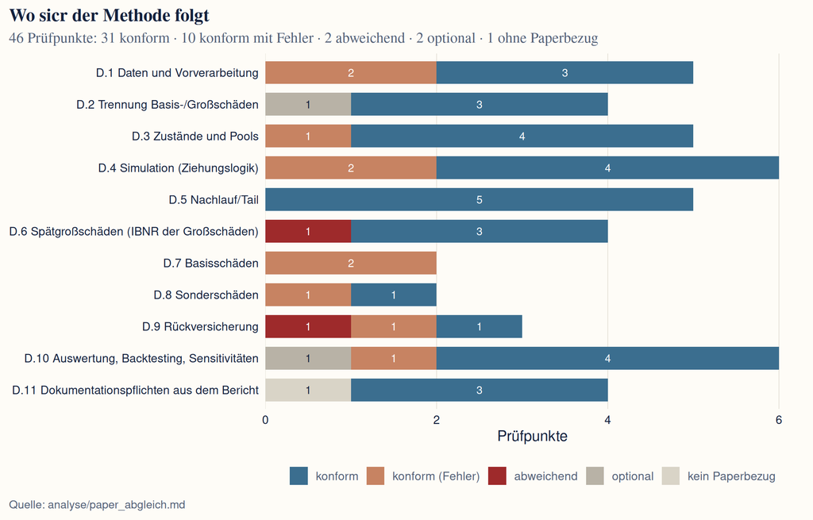

Jeder Balken zählt die Prüfpunkte eines Methodenschritts. Die Checkliste ist aus Kapitel 2 des Berichts abgeleitet; der Bericht selbst hat keinen Anhang D.

## Das Gesamturteil

PRÜFPUNKTE · EIGENE CHECKLISTE D.1–D.11

31

konform

10

konform mit Fehler

2

abweichend: D.6.1, D.9.1

2

optional: D.2.2, D.10.3

1

ohne Paperbezug: D.11.4

Der DAV-Bericht hat keinen Anhang D; die 46 Punkte sind eine eigene Checkliste, aus Kapitel 2 (S. 10–19) abgeleitet.

## Wo sich Ergebnisse am stärksten bewegen

WIRKUNG · BEISPIELDATEN

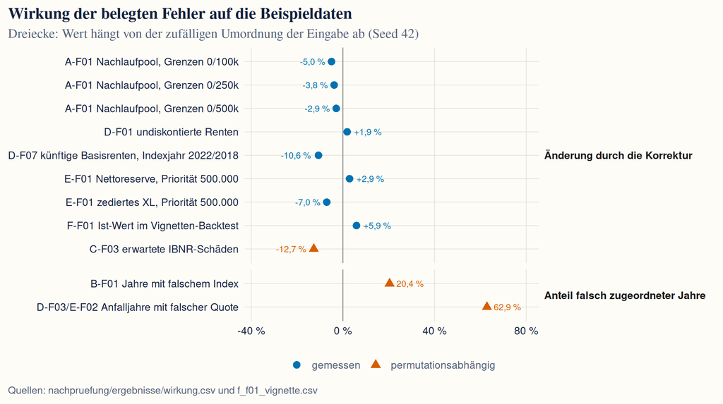

## D.1 Daten und Indizierung

DATEN · D.1

### Folge

**B-F01 (hoch)** ordnet historische Indizes nach Zeilenposition statt nach `Calendar_year` zu. Bei unsortierter Eingabe erhalten **20,4 %** der Jahre einen falschen Index.

Dasselbe Muster zeigt sich bei **C-F03**, **D-F03** und **E-F02**: Exposure und Quoten werden ebenfalls positionsabhängig zugeordnet.

### Nicht betroffen

Die übrigen Schritte der Indexierung und Datenaufbereitung folgen der Methode. sicr löst dieselbe Zuordnung an anderer Stelle bereits richtig mit `match()`, etwa in der Rückversicherung.

Die Korrekturen übernehmen dieses Muster, statt die Sortierung der Eingabe vorauszusetzen.

data_functions.R:47–49 · expand_historic_indices() · reinsurance.R:296 · match()

## D.3/D.5 Nachlauf

NACHLAUF · D.5

-4,95 %

Nachlaufpoolmasse, Grenzen 0 / 100 Tsd.

-3,82 %

Nachlaufpoolmasse, Grenzen 0 / 250 Tsd.

-2,90 %

Nachlaufpoolmasse, Grenzen 0 / 500 Tsd.

Die Nachlaufdefinition selbst und die lineare Skalierung folgen der Methode; betroffen ist nur die Reihenfolge von Kappung und Hochskalierung. In der Checkliste ist A-F01 dem Schritt D.3 zugeordnet.

generate_pools.R:130–139 · Grenzen nach der Hochskalierung

## D.6 Spätgroßschäden

IBNR · D.6

### Folge

**C-F03 (hoch)** ordnet die Bestandsgrößen der Exposure nach Zeilenposition statt nach Anfalljahr zu. Im Permutationsfall stehen **38,3** statt **43,9** erwartete IBNR-Schäden (-12,7 %).

Der Wert hängt von der zufälligen Zeilenreihenfolge der Eingabe ab; er ist eine Illustration des Mechanismus, kein fester Punktwert.

### Abweichung D.6.1

Das additive Modell lässt das letzte Abwicklungsjahr N weg (**C-F05**), dessen Spätgroßschäden damit nicht zählen. C-F03 verschiebt die Bestandsgrößen zusätzlich positionsabhängig statt nach Anfalljahr.

Die übrige Kette – additive Anzahlen, Rundung, Höhe aus dem IBNR-Pool – folgt der Methode.

ibnr.R:104–118 · exposure; ibnr.R:49 · letztes Abwicklungsjahr

## D.7 Basisschäden und Renten

RENTEN · D.7

-10,6 %

D-F07: künftige Basisrenten bei zwei Indexjahren

+1,86 %

D-F01: undiskontierte Rentenzahlungen

62,9 %

D-F03: Anfalljahre mit falscher Quote

**D-F07 (hoch)** macht das Ergebnis der künftigen Basisrenten vom gewählten Indexjahr abhängig. **D-F01 (mittel)** setzt die Sterblichkeit bekannter Renten um ein Lebensjahr zu jung an. **D-F03 (hoch)** ordnet die Quota-Share-Rückversicherung positionsabhängig statt nach Anfalljahr zu.

annuity_functions.R:161, 172 · small_claims_future_annuities.R:311–315 · small_claims.R:613

## D.9 Rückversicherung

RÜCKVERSICHERUNG · D.9

### Wirkung

**E-F01 (hoch)** lässt den XL-Anteil der IBNR-Zeilen in der Aggregation fehlen. Auf den Beispieldaten ist die Wirkung **0,0 %**.

Mit Priorität 500.000 ändert die Korrektur das zedierte XL um **-7,04 %** und die Nettoreserve um **+2,91 %**.

**E-F02 (hoch)** ordnet die Quote über die Zeilenposition zu; im Permutationsfall betrifft das **62,9 %** der Anfalljahre.

### Nicht betroffen / Abweichung

Die Zusammenfassung von `sicr()` selbst ist nicht betroffen; nur die aggregierten Brutto-/Netto-Sichten weichen ab.

**D.9.1 (abweichend):** AAD/AAL sind nicht implementiert. Zusätzlich verankert C-F04 die Indexklausel ein Jahr zu früh, C-F02 betrifft nur die Ausgabewahl.

sicr.R:592 · aggregate_large_claims_results.R:181 · reinsurance.R:296 · xl_cashflow()

## D.10 Auswertung und Backtesting

BACKTESTING · D.10

### Folge

**F-F01 (hoch)** vergleicht nominale Prognosen mit auf das Indexjahr deflationierten Ist-Zahlungen. Im Vignetten-Backtesting ist der Bias-Faktor **1,0595**; die Korrektur hebt den Ist-Wert um **+5,95 %** an.

### Nicht betroffen

Die Backtesting-Struktur selbst entspricht dem Bericht: prognostizierte und tatsächliche Zahlung des ersten Folgejahres werden gegenübergestellt.

Der Ultimate-Backtest (D.10.3) bleibt optional; das Paket implementiert ihn nicht.

plots.R:1239, 1466 · Ind_cl_payment_cal · plots.R:1209–1350

## Die übrigen Fehler

ALLE FEHLER · NACH METHODENSCHRITT

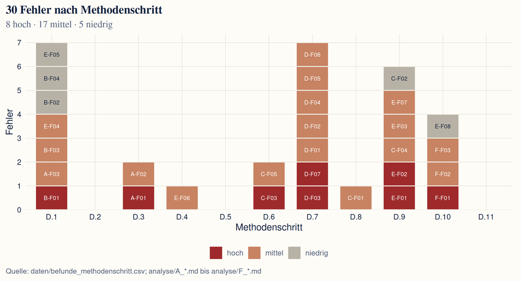

Das Bild zeigt alle 30 Fehler an ihrem Methodenschritt: 8 sind hoch, 17 mittel und 5 niedrig. Leere Schritte bleiben sichtbar.

## Schneller bei gleichem Ergebnis

VERBESSERUNGEN · BENCHMARKS

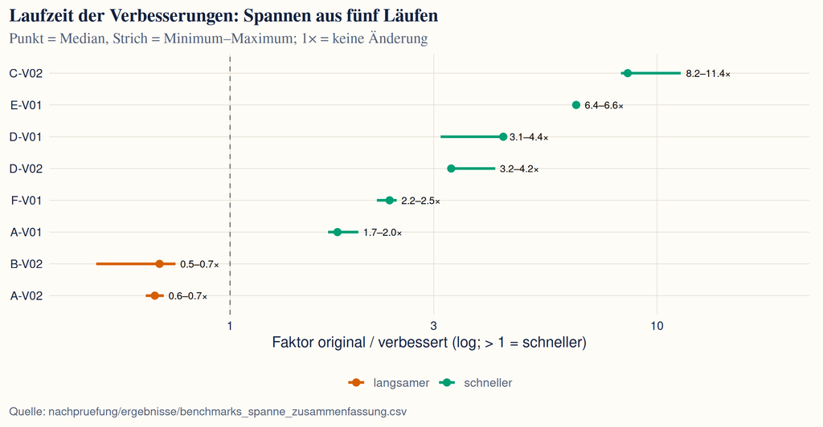

Jede der 12 Verbesserungen hat einen Gleichheitstest gegen das Original; die Grafik zeigt die gemessenen Laufzeit-Spannen aus fünf Läufen.

## Empfehlungen

NACH WIRKUNG AUF DIE RESERVE

1. **D-F07 zuerst beheben:** Die künftigen Basisrenten dürfen nicht vom Indexjahr abhängen; bei zwei Indexjahren sind es -10,6 %.
2. **A-F01 korrigieren:** Ausreißergrenzen im Nachlauf vor der Hochskalierung anwenden; die Poolmasse verschiebt sich um -4,95 % bei Grenzen 0 / 100 Tsd.
3. **E-F01 in der Aggregation schließen:** Den XL-Anteil der IBNR-Zeilen mitführen; bei Priorität 500.000 ändert sich die Nettoreserve um +2,91 %.
4. **D-F01 altersrichtig stellen:** Die Sterblichkeit bekannter Renten ab q(x+1) ansetzen; die undiskontierten Zahlungen ändern sich um +1,86 %.
5. **Positionszuordnung durch `match()` ersetzen:** B-F01, C-F03, D-F03 und E-F02; bei B-F01 betrifft die Permutation 20,4 % der Jahre.
6. **F-F01 im Backtesting korrigieren:** Nominal gegen nominal vergleichen; im Vignettenfall hebt die Korrektur den Ist-Wert um +5,95 %.

## Grenzen

EINORDNUNG

- Die Befunde gelten für sicr 1.1.1 (Commit c0ad2ad); neuere Versionen wurden nicht geprüft.
- Die Fehlertests nutzen kleine konstruierte Eingaben. Wie stark ein Fehler auf eine echte Reserve wirkt, ist nur dort beziffert, wo `wirkung.csv` oder `f_f01_vignette.csv` Zahlen liefern.
- Die Permutationszahlen zu B-F01, C-F03 und D-F03/E-F02 hängen von der Zeilenreihenfolge ab; sie illustrieren den Mechanismus, sie sind keine festen Punktwerte.
- Die Korrekturen sind einzelne Funktionen zum Nachvollziehen, kein gepflegter Fork von sicr.
- Der DAV-Bericht liegt aus urheberrechtlichen Gründen nicht im Repo; zitiert wird mit Seitenzahl.

## Anhang · Belastbarkeit

PRÜFRUNDEN · TESTS

Drei Prüfrunden – Audit, Gegenprüfung (oc1) und Nachprüfung (cl1) – bestätigen die Befunde; Einzelheiten stehen in `nachpruefung/bericht.md`.

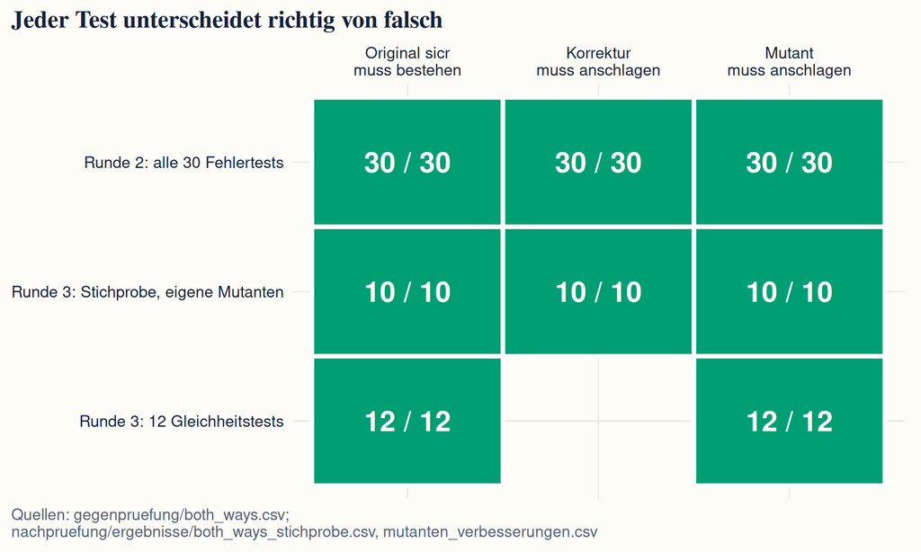

github.com/56eli/aktuar2